# FINALS

Harry Wang

2024-05-06

### Q1

```r
library(readxl)
pabmi = read_xls("./pabmi.xls")
library(knitr)
```

```r
with(pabmi,cor(PA,BMI))
```

```
## [1] -0.3854091
```

```r
with(pabmi,cor.test(PA,BMI))
```

```
##
##  Pearson's product-moment correlation
##
## data:  PA and BMI
## t = -4.1348, df = 98, p-value = 7.503e-05
## alternative hypothesis: true correlation is not equal to 0
## 95 percent confidence interval:
##  -0.5408817 -0.2044696
## sample estimates:
##        cor
## -0.3854091
```

The p-value for testing the null hypothesis $H_0: p(X,Y) = 0$ is 7.503e-05 , which is less than the significance level $\alpha = 0.05$. This result allows us to reject the null hypothesis, indicating that the correlation between PA and BMI is statistically significant and not zero.

### Q2

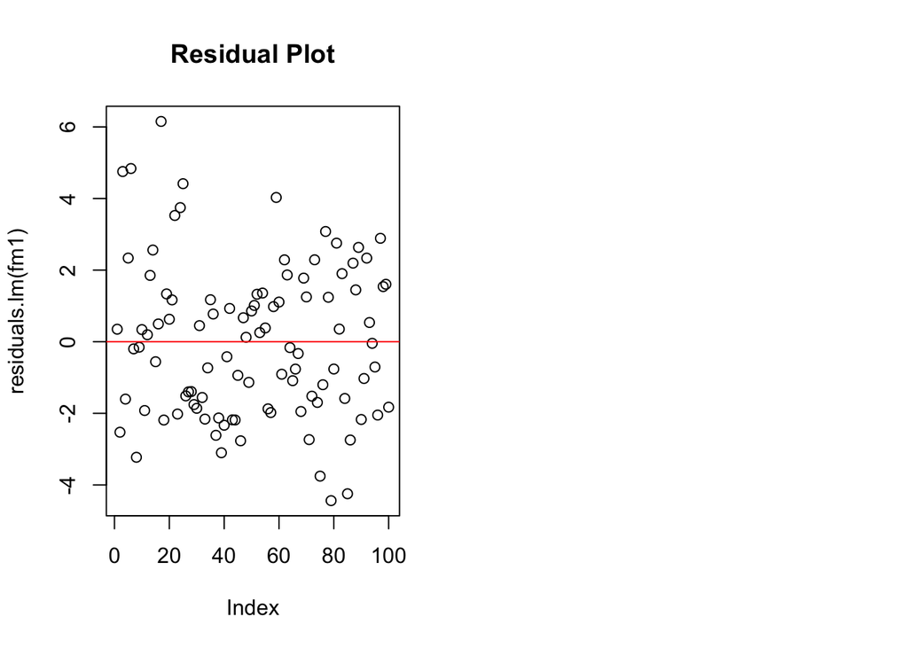

```r
fm1 = lm(PA ~ BMI, data = pabmi)

par(mfrow=c(1,2))
plot(residuals.lm(fm1),main="Residual Plot")
abline(0,0,col="red")

par(mfrow=c(1,2))
```

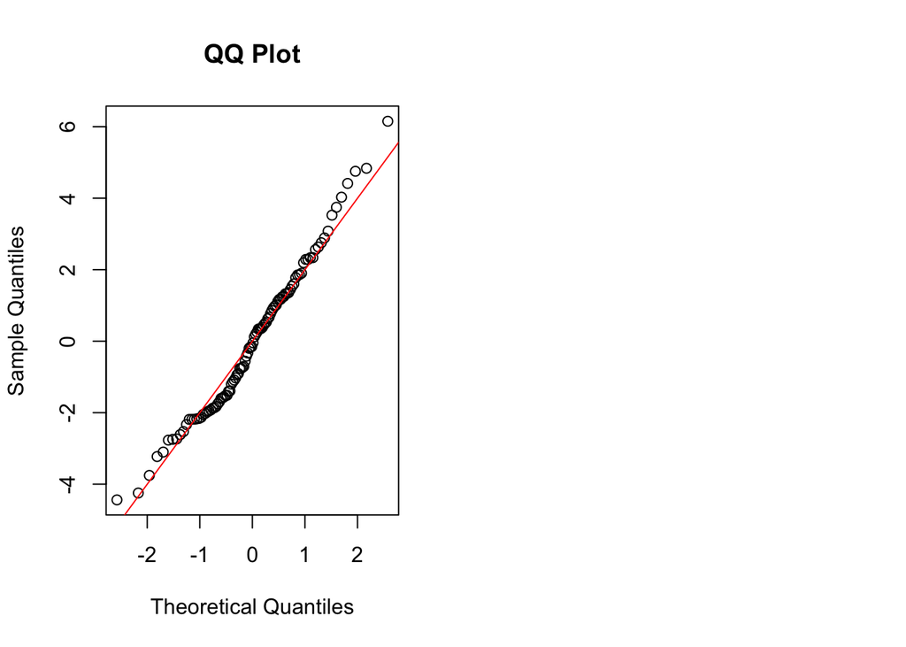

```r
qqnorm(residuals(fm1),main="QQ Plot")
abline(0,2, col="red")
```

### Q3

```r
model <- lm(BMI ~ PA, data = pabmi)
summary_model <- summary(model)
intercept <- coef(model)[1]
slope <- coef(model)[2]
print(paste("Intercept (beta_0):", intercept))
```

```
## [1] "Intercept (beta_0): 29.5782471400245"
```

```r
print(paste("Slope (beta_1):", slope))
```

```
## [1] "Slope (beta_1): -0.654685765768194"
```

```r
cat("Regression Equation: BMI = 29.578 - 0.655 x PA")
```

```
## Regression Equation: BMI = 29.578 - 0.655 x PA
```

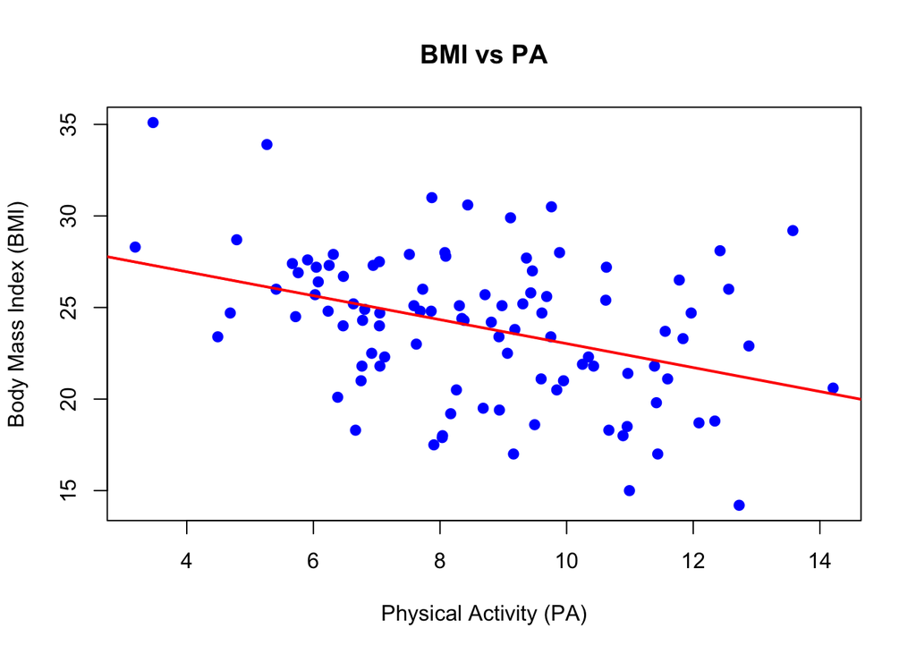

```r
plot(pabmi$PA, pabmi$BMI, main = "BMI vs PA", xlab = "Physical Activity (PA)", ylab = "Body Mass Index (BMI)", pch = 19, col = "blue")
abline(model, col = "red", lwd = 2)
```

### Q4

```r
print(summary_model)
```

```
##
## Call:
## lm(formula = BMI ~ PA, data = pabmi)
##
## Residuals:
##     Min      1Q  Median      3Q     Max
## -7.3819 -2.5636  0.2062  1.9820  8.5078
##
## Coefficients:
##             Estimate Std. Error t value Pr(>|t|)
## (Intercept)  29.5782     1.4120  20.948  < 2e-16 ***
## PA           -0.6547     0.1583  -4.135  7.5e-05 ***
## ---
## Signif. codes:  0 '***' 0.001 '**' 0.01 '*' 0.05 '.' 0.1 ' ' 1
##
## Residual standard error: 3.655 on 98 degrees of freedom
## Multiple R-squared:  0.1485, Adjusted R-squared:  0.1399
## F-statistic:  17.1 on 1 and 98 DF,  p-value: 7.503e-05
```

The hypothesis test for the slope parameter in the regression model of BMI as a function of PA yields a p-value of 7.5e-05, which is significantly less than the conventional alpha level of 0.05. This indicates strong statistical evidence to reject the null hypothesis that the slope is zero. Therefore, we conclude that there is a significant negative relationship between PA (Physical Activity) and BMI (Body Mass Index), suggesting that increases in PA are associated with decreases in BMI.

### Q5

```r
conf_interval <- confint(model, "PA", level = 0.95)
print(conf_interval)
```

```
##         2.5 %     97.5 %
## PA -0.9688987 -0.3404729
```

### Q6

```r
kable(anova(fm1))
```

|  | Df | Sum Sq | Mean Sq | F value | Pr(>F) |
| --- | --- | --- | --- | --- | --- |
| BMI | 1 | 79.14633 | 79.146326 | 17.09644 | 7.5e-05 |
| Residuals | 98 | 453.68153 | 4.629403 | NA | NA |

### Q7

```r
anova_results <- anova(model)
r_squared <- summary_model$r.squared
ssm <- anova_results$"Sum Sq"[1]
sst <- ssm + anova_results$"Sum Sq"[2]
print(paste("R-squared: ", r_squared))
```

```
## [1] "R-squared:  0.148540142707423"
```

```r
print(paste("SSM (Sum of Squares Model): ", ssm))
```

```
## [1] "SSM (Sum of Squares Model):  228.37718667551"
```

```r
print(paste("SST (Total Sum of Squares): ", sst))
```

```
## [1] "SST (Total Sum of Squares):  1537.4779"
```

### Q8

```r
# New data for prediction
new_data <- data.frame(PA = 27.85)

# Predict the expected value of Y and the confidence interval
predictions <- predict(model, newdata = new_data, interval = "confidence", level = 0.95)
print(predictions)
```

```
##        fit      lwr      upr
## 1 11.34525 5.257584 17.43291
```

### Q9

```r
observation = data.frame(PA = 31.25)
predict(model,newdata=observation,interval="prediction",level=0.9)
```

```
##        fit      lwr      upr
## 1 9.119317 0.597295 17.64134
```

### Q10

```r
fm2= lm(BMI ~ poly(PA,2), data=pabmi)
summary(fm2)
```

```
##
## Call:
## lm(formula = BMI ~ poly(PA, 2), data = pabmi)
##
## Residuals:
##     Min      1Q  Median      3Q     Max
## -8.1159 -2.3779  0.1315  2.2638  7.7518
##
## Coefficients:
##              Estimate Std. Error t value Pr(>|t|)
## (Intercept)   23.9390     0.3612  66.285  < 2e-16 ***
## poly(PA, 2)1 -15.1122     3.6115  -4.184 6.28e-05 ***
## poly(PA, 2)2   6.6269     3.6115   1.835   0.0696 .
## ---
## Signif. codes:  0 '***' 0.001 '**' 0.01 '*' 0.05 '.' 0.1 ' ' 1
##
## Residual standard error: 3.612 on 97 degrees of freedom
## Multiple R-squared:  0.1771, Adjusted R-squared:  0.1601
## F-statistic: 10.44 on 2 and 97 DF,  p-value: 7.838e-05
```

### Q11

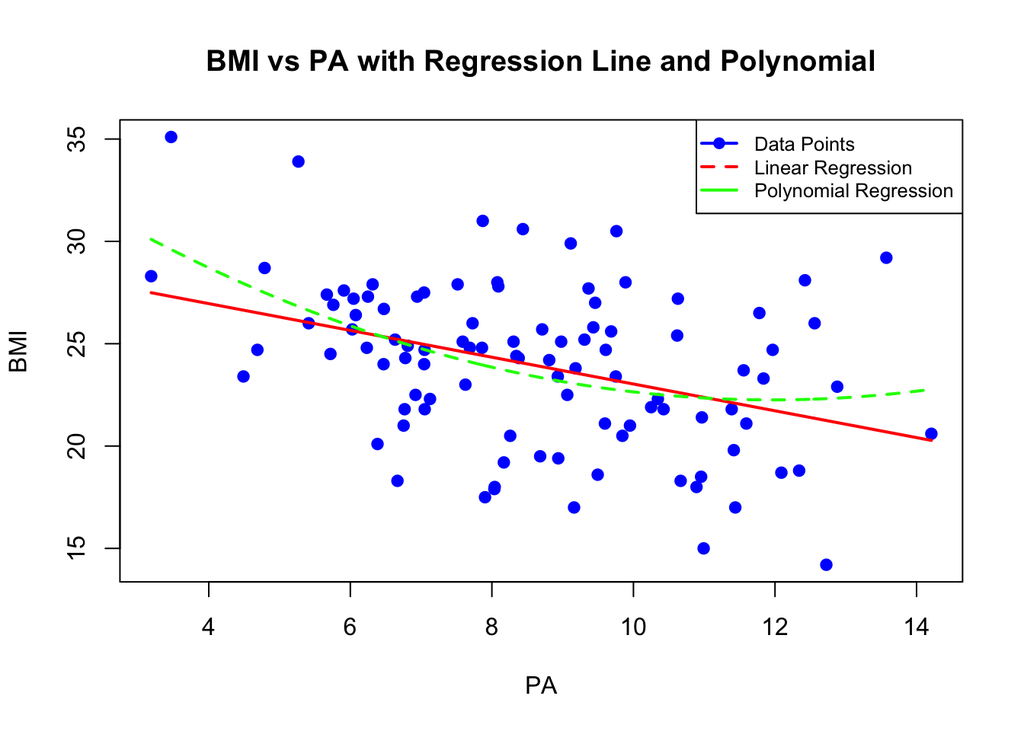

```r
# Fit the linear model
linear_model <- lm(BMI ~ PA, data = pabmi)

# Fit the second-degree polynomial model
poly_model <- lm(BMI ~ PA + I(PA^2), data = pabmi)

# Create a sequence of PA values for predictions
pa_values <- seq(min(pabmi$PA), max(pabmi$PA), length.out = 300)
# Predict BMI for linear model
predicted_bmi_linear <- predict(linear_model, newdata = data.frame(PA = pa_values))

# Predict BMI for polynomial model
predicted_bmi_poly <- predict(poly_model, newdata = data.frame(PA = pa_values))
# Plot the original data points
plot(pabmi$PA, pabmi$BMI, main = "BMI vs PA with Regression Line and Polynomial",
     xlab = "PA", ylab = "BMI", pch = 19, col = "blue")

# Add the linear regression line
lines(pa_values, predicted_bmi_linear, col = "red", lwd = 2)

# Add the second-degree polynomial regression line
lines(pa_values, predicted_bmi_poly, col = "green", lwd = 2, lty = 2)

# Add a legend
legend("topright", legend = c("Data Points", "Linear Regression", "Polynomial Regression"),
       col = c("blue", "red", "green"), lty = 1:2, cex = 0.8, pch = c(19, NA, NA), lwd = 2)
```

### Q12

$Y = \begin{bmatrix} y_1 \\ y_2 \\ \vdots \\ y_n \end{bmatrix}$